# Single cell RNAseq analysis of hepatoblastoma dataset

Nia Hall

2026-07-02

## Load datasets

Hepatoblastoma is one of the primary liver cancers in young children, with the disease typically manifesting in children under 4 year of age $^1$. The following analysis uses a hepatoblastoma dataset from a 2021 study in which investigators sought to use single cell RNAseq to identify cell populations and molecular pathways that serve as key drivers of the disease $^2$. This dataset can be found using the following Gene Expression Omnibus accession number (GSE180666).

```r
library(Seurat)
library(harmony)
library(patchwork)
library(tidyverse)
library(presto)
```

```r
# read in data from healthy patients
normal.HB17.counts <- Read10X("HB17_background")
normal.HB53.counts <- Read10X("HB53_background")

# read in data from cancer patients
cancer.HB30.counts <- Read10X("HB30_tumor")
cancer.HB53.counts <- Read10X("HB53_tumor")
cancer.HB17.counts <- Read10X("HB17_tumor")
```

```r
# create seurat objects for healthy patients
normal.HB17 <-  CreateSeuratObject(counts = normal.HB17.counts,
                                   project = "HB17_background")
normal.HB53 <- CreateSeuratObject(counts = normal.HB53.counts,
                                  project = "HB53_background")

# create seurat objects for tumor patinets
cancer.HB30 <-  CreateSeuratObject(counts = cancer.HB30.counts,
                                   project = "HB30_tumor")
cancer.HB53 <- CreateSeuratObject(counts = cancer.HB53.counts,
                                  project = "HB53_tumor")
cancer.HB17 <- CreateSeuratObject(counts = cancer.HB17.counts,
                                  project = "HB17_tumor")

# remove the counts data, that is no longer needed
rm(normal.HB17.counts,normal.HB53.counts,cancer.HB17.counts,
   cancer.HB30.counts,cancer.HB53.counts)

# merge dataset
merged <- merge(normal.HB17, y = c(normal.HB53,cancer.HB17,cancer.HB30,
                                   cancer.HB53),
                add.cell.ids = c("normal_HB17", "normal_HB53", "cancer_HB17",
                                 "cancer_HB30", "cancer_HB53"),
                project = "merged")

# create a sample column
merged$sample <- rownames(merged@meta.data)

# split sample column into Patient, Type, and Barcode columns
merged@meta.data <- separate(merged@meta.data, col = 'sample',
                             into = c('Patient', 'Type', 'Barcode'),
                             sep = '_')
```

## Quality control and filtering

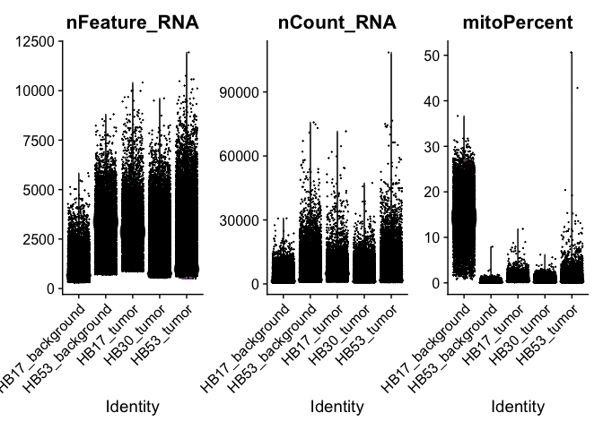

Figure 1. Quality control metrics for Feature counts, RNA counts, and percent mitochondrial genes.

```r
merged$mitoPercent <- PercentageFeatureSet(merged, pattern='^MT-')
VlnPlot(merged, features = c("nFeature_RNA", "nCount_RNA", "mitoPercent"),
        ncol = 3)
```

After examining the above violin plots, one can see that one of the background samples (HB17_background) contains a high percentage of mitochondrial genes relative to the rest of the samples. Coupled with low features counts, such results could be indicative of a large proportion of dead or damaged cells. The following thresholds will be used to filter the dataset: nCount_RNA > 800 and nFeature_RNA > 500. Since it is normal for cancer cells to have high metabolic rates (and thus higher mitochondrial expression) the mitoPercent < 10 will be the mitochondrial threshold.

```r
# filter dataset based on gene, feature, and mitochondrial gene count
merged_seurat_filtered <- subset(merged, subset = nCount_RNA > 800 &
                                         nFeature_RNA > 500 &
                                         mitoPercent < 10)
```

After filtering we are left with a total of 49727 cells and 33538 genes.

## Data preprocessing

### Normalization, scaling and PCA

After performing quality control, a series of of preprocessing steps will need to be implemented. Normalization will transform the raw data so that the expression of each gene is comparable across cells as a proportion of total counts. FindVariableFeatures identifies the top 2000 genes most responsible for the variability in the data, while scaling gives genes across each cell a mean of 0 and a variance of 1. This will prevent highly expressed genes from dominating how cells are clustered relative to each other. Lastly, PCA will conduct dimensionality reduction, generating PCs composed of combinations of genes that are believed to be responsible for most of the variability in the dataset.

```r
# remove seurat objects, since they are no longer needed
rm(cancer.HB17,cancer.HB30,cancer.HB53,normal.HB17,normal.HB53, merged)

# perform standard workflow, normalizing, scaling data, and
# conducting dimensionality reduction
merged_seurat_filtered <- NormalizeData(merged_seurat_filtered)
merged_seurat_filtered <- FindVariableFeatures(merged_seurat_filtered)
merged_seurat_filtered <- ScaleData(merged_seurat_filtered)
merged_seurat_filtered <- RunPCA(merged_seurat_filtered)
```

### Perform data integration

The integration step is essential for ensuring cell types across treatments groups and batches cluster together. Harmony will be used instead of Seurat’s CCA for its speed and ability to handle batch effects without over-correcting and potentially removing biological signal.

```r
#integrate layers
merged_seurat_filtered <- IntegrateLayers(
  object = merged_seurat_filtered, method = HarmonyIntegration,
  orig.reduction = "pca", new.reduction = "harmony",
  verbose = FALSE
)
# re-join layers after integration
merged_seurat_filtered[["RNA"]] <- JoinLayers(merged_seurat_filtered[["RNA"]])
```

## Generate clusters

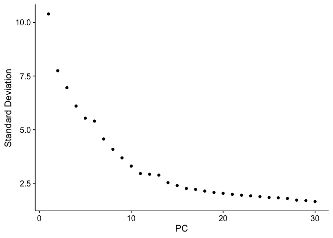

Figure 2. Elbow plot displaying the standard deviation scores for 30 principal components.

```r
# identify the ideal number of PCs to include
ElbowPlot(merged_seurat_filtered, n=30)
```

```r
merged_seurat_filtered <- FindNeighbors(merged_seurat_filtered,
                                        reduction = "harmony", dims = 1:30)
merged_seurat_filtered <- FindClusters(merged_seurat_filtered,
                                       resolution = 0.3)
```

```
## Modularity Optimizer version 1.3.0 by Ludo Waltman and Nees Jan van Eck
##
## Number of nodes: 49727
## Number of edges: 1782659
##
## Running Louvain algorithm...
## Maximum modularity in 10 random starts: 0.9569
## Number of communities: 18
## Elapsed time: 16 seconds
```

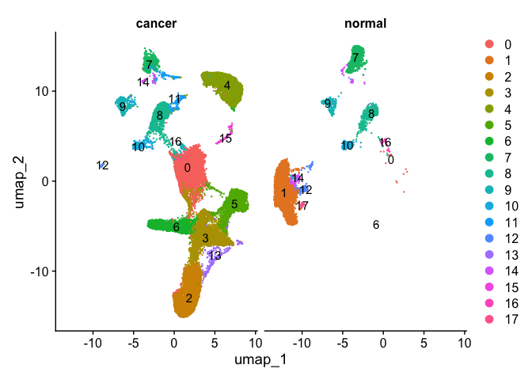

Figure 3. UMAPs for cancer and normal samples.

```r
# create umap
merged_seurat_filtered <- RunUMAP(merged_seurat_filtered,
                                  dims = 1:30, reduction = "harmony")
# Visualization
DimPlot(merged_seurat_filtered, reduction = "umap", label = T,
        split.by = "Patient")
```

## Manual annotation of cell clusters

Differentially expressed genes that define clusters will be extracted and plugged into PangaoDB, Cellmarker 2.0, and Claude in order to identify the most likely cell types that make each cluster. Cluster 7 and 14 are composed of endothelial cells (EGFL7, and FLT1), cluster 8 and 11 of kupffer/M2 cells (CD163, CSF1R, C1QA, MRC1, MSR1, and MARCH1), cluster 15 of erythrocytes (HBB, HBA1, HBA2, and GYPA), cluster 10 of exhausted memory CD8T cells (CD247, PTPRC, LCK, CCR7, SLAMF6, RUNX3), cluster 9 of hepatic satellite cells (COL1A2, COL3A1, and MYL9), cluster 12 of biliary/cholangiocytes (KRT19, MMP7, and KRT7), cluster 1, 17, and 16 of normal hepatocytes (CYP3A4), and cluster 13 of neurons (NRP2, TGFB2, NRCAM, and NFASC). Clusters 0,4,5,3,6, and 2 make up tumor cells.

```r
# CLUSTERS 7 and 14  consists of endothelial cells
cluster.7.14 <- FindConservedMarkers(merged_seurat_filtered, ident.1 = c(7,14),
                                   grouping.var = "Patient", verbose = FALSE)
cluster.7.14$gene_names <- rownames(cluster.7.14)
m.7.14 <- paste(head(cluster.7.14$gene_names,30), collapse = ",")

# CLUSTER 8 and 11 consists kupffer/M2 cells
cluster.8.11 <- FindConservedMarkers(merged_seurat_filtered, ident.1 = c(8,11),
                                   grouping.var = "Patient", verbose = FALSE)
cluster.8.11$gene_names <- rownames(cluster.8.11)
m.8.11 <- paste(head(cluster.8.11$gene_names,30), collapse = ",")

# CLUSTER 15 consists of erythrocytes
cluster.15 <- FindConservedMarkers(merged_seurat_filtered, ident.1 = 15,
                                   grouping.var = "Patient", verbose = FALSE)
cluster.15$gene_names <- rownames(cluster.15)

# CLUSTER 10 consists of exhausted memory T cells
cluster.10 <- FindConservedMarkers(merged_seurat_filtered, ident.1 = 10,
                                   grouping.var = "Patient", verbose = FALSE)
cluster.10$gene_names <- rownames(cluster.10)
m10 <- paste(head(cluster.10$gene_names,30), collapse = ",")

# CLUSTER 9 consists of hepatic stellate cells
cluster.9 <- FindConservedMarkers(merged_seurat_filtered, ident.1 = 9,
                                   grouping.var = "Patient", verbose = FALSE)
cluster.9$gene_names <- rownames(cluster.9)
m9 <- paste(head(cluster.9$gene_names,30), collapse = ",")

# CLUSTER 12 consists of biliary/cholangiocytes
cluster.12 <- FindConservedMarkers(merged_seurat_filtered, ident.1 = 12,
                                   grouping.var = "Patient", verbose = FALSE)
cluster.12$gene_names <- rownames(cluster.12)
m12 <- paste(head(cluster.12$gene_names,15), collapse = ",")

# CLUSTER 1, 16, and 17 consists of normal hepatocytes
cluster.17.16.1 <- FindConservedMarkers(merged_seurat_filtered,
                                        ident.1 = c(17,16,1),
                                   grouping.var = "Patient", verbose = FALSE)
cluster.17.16.1$gene_names <- rownames(cluster.17.16.1)
m17.16.1 <- paste(head(cluster.17.16.1$gene_names,30), collapse = ",")

# CLUSTER 13 consists of neurons
cluster.13 <- FindConservedMarkers(merged_seurat_filtered, ident.1 = 13,
                                   grouping.var = "Patient", verbose = FALSE)
cluster.13$gene_names <- rownames(cluster.13)
m13 <- paste(head(cluster.13$gene_names,30), collapse = ",")
```

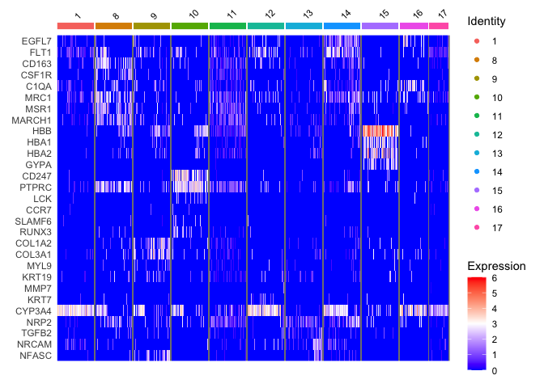

Figure 4. Heatmap of marker genes

```r
# generate heatmap of non-tumor clusters
non.tumor.genes <- c("EGFL7", "FLT1", "CD163", "CSF1R", "C1QA", "MRC1", "MSR1",
                     "MARCH1", "HBB", "HBA1", "HBA2", "GYPA", "CD247", "PTPRC",
                     "LCK", "CCR7", "SLAMF6", "RUNX3", "COL1A2", "COL3A1",
                     "MYL9", "KRT19", "MMP7", "KRT7", "CYP3A4", "NRP2",
                     "TGFB2", "NRCAM", "NFASC")
DoHeatmap(subset(merged_seurat_filtered, downsample = 100,
                 idents = c(1,8,9,10,11,12,13,14,15,16,17)),
          features = non.tumor.genes, size = 3, slot = "data") +
          scale_fill_gradientn(colors = c("blue", "white", "red"))
```

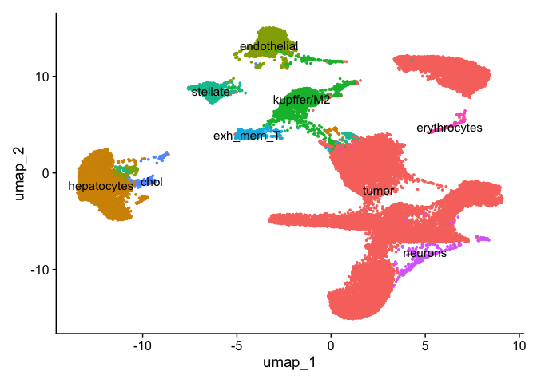

Figure 5. UMAP of annotated clusters

```r
new.cluster.ids <- c("tumor", "hepatocytes", "tumor", "tumor", "tumor",
                     "tumor","tumor", "endothelial", "kupffer/M2", "stellate",
                     "exh_mem_T", "kupffer/M2", "chol", "neurons",
                     "endothelial", "erythrocytes", "hepatocytes",
                     "hepatocytes")
names(new.cluster.ids) <- levels(merged_seurat_filtered)
merged_seurat_filtered <- RenameIdents(merged_seurat_filtered,
                                       new.cluster.ids)
merged_seurat_filtered$celltypes <- Idents(merged_seurat_filtered)
DimPlot(merged_seurat_filtered, reduction = "umap", label = TRUE,
        pt.size = 0.5) + NoLegend()
```

```r
# a new metadata column called celltype.stim will be created for differential
# gene expression analysis.
merged_seurat_filtered$celltype.stim <- paste(merged_seurat_filtered$celltypes, merged_seurat_filtered$Patient, sep = "_")
Idents(merged_seurat_filtered) <- "celltype.stim"
```

## Differential gene expression

After identifying major cell types the next step is to perform differential gene expression analysis. Focus will center on the non-tumor cell populations of the dataset. It should be noted that because the normal samples only consist of 2 replicates, pseudo-bulk aggregated methods cannot be used. Wilcoxon will be used instead, with stringent filtering to handle the test’s tendency to produce false positives do to its treatment of each cell as a replicate.

```r
# endothelial
endo.de <- FindMarkers(merged_seurat_filtered, ident.1 = "endothelial_cancer",
                       ident.2 = "endothelial_normal",test.use = "wilcox",
                       verbose = FALSE, slot = "data")
endo.de <- endo.de[endo.de$p_val_adj < 0.01 & (endo.de$avg_log2FC > 1.5 |
                           endo.de$avg_log2FC < -1.5), ]
endo.de$gene_names <- rownames(endo.de)
endo.up.genes <- rownames(endo.de)

# kupffer/M2
kupffer.de <- FindMarkers(merged_seurat_filtered,ident.1 = "kupffer/M2_cancer",
                          ident.2 = "kupffer/M2_normal",test.use = "wilcox",
                          verbose = FALSE, slot = "data")
kupffer.de <- kupffer.de [kupffer.de$p_val_adj < 0.01 &
                                  (kupffer.de$avg_log2FC > 1.5 |
                                  kupffer.de$avg_log2FC < -1.5), ]
kupffer.de$gene_names <- rownames(kupffer.de)
kupffer.up.genes <- paste(rownames(kupffer.de), collapse = ",")

# exhausted memory t cells
mt.de <- FindMarkers(merged_seurat_filtered, ident.1 = "exh_mem_T_cancer",
                     ident.2 = "exh_mem_T_normal",test.use = "wilcox",
                     verbose = FALSE, slot = "data")
mt.de <- mt.de [mt.de$p_val_adj < 0.01 & (mt.de$avg_log2FC > 1.5 |
                        mt.de$avg_log2FC < -1.5), ]
mt.de$gene_names <- rownames(mt.de)
mt.up.genes <- paste(rownames(mt.de), collapse = ",")

# stellate cells
ste.de <- FindMarkers(merged_seurat_filtered, ident.1 = "stellate_cancer",
                      ident.2 = "stellate_normal",test.use = "wilcox",
                      verbose = FALSE, slot = "data")
ste.de <- ste.de [ste.de$p_val_adj < 0.01 & (ste.de$avg_log2FC > 1.5 |
                          ste.de$avg_log2FC < -1.5), ]
ste.de$gene_names <- rownames(ste.de)
ste.up.genes <- paste(rownames(ste.de), collapse = ",")
```

For endothelial cells, noteworthy upregulated genes include HIF-1 alpha and VEGFC. There is a phenomenon in in Hepatoblastoma known as the Warburg effect. In this situation tumors tend to produce energy via glycolosis rather than oxidative phosphorylation${^3}$. This acidic environment results in HIF-1 alpha and VEGF production in endothelial cells, promoting angiogenesis. The kupffer cell cluster appears to be composed of cells that are shifting to an M2 macrophage state. Important up-regulated genes in cancer tissue include SPP1 (found to be involved in stemness, chemoresistance, immunosuppression, and angiogenesis ${^4}$), CSF1 (involved in establishing a tumor associated macrophage (TAM) recruitment loop, M2 polarization${^5}$, MMP2/MMP14 (involved in extracellular matrix degeneration, invasion, and metastasis ${^6}$, and ANGPT2 (involved in tumor angiogenesis and vascular remodeling${^7}$).

Exhausted memory T cells in cancer tissue have high levels of genes expressed involved in exhaustion and immune suppression (IKZF2, ICOS, and SLAMF1$^{8,9,10}$), impairing the bodies ability to attack and reverse cancer cell expansion. Stellate cells in cancer tissues were up-regulated in FAP, IL34, ANGPT2, and VCAM1, which play a roles in TAM recruitment/M2 polarization, angiogenesis, immune cell retention and erythroblastic island formation respectively. While there is little evidence to show that stellate cells express these genes, they are elevated in cancer associated fibroblasts. These cells develop from hepatic stellate cells and can support tumorgenesis by stimulating proliferation, angiogenesis and remodeling the micro-environment $^{11}$. IL-34 has been found to be up-regulated in several cancers, and studies like the one conducted by Franze et al. on colorectal cancer revealed that CAF secreted IL-34 led to the promotion of cancer growth/migration via netrin-1 and basic-fibroblast growth factor $^{12}$. Similar mechanisms could be at play in hepatoblastoma. Other studies have found ANGPT2 up-regulation driving pro-angiogenic activity $^{13}$, and VCAM-1 enhancing the growth and invasion of cancer $^{14}$.

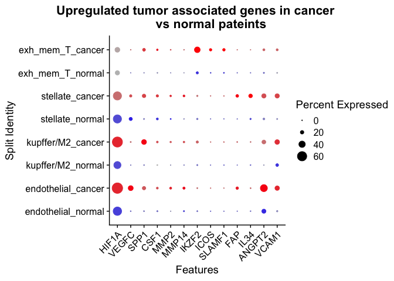

Figure 6. Upregualted Tumor associated genes in non-tumor cells

```r
Idents(merged_seurat_filtered) <- "celltypes"
de.genes <- c("HIF1A", "VEGFC", "SPP1", "CSF1", "MMP2", "MMP14", "IKZF2",
              "ICOS", "SLAMF1", "FAP", "IL34", "ANGPT2", "VCAM1")
DotPlot(subset(merged_seurat_filtered, idents = c("endothelial", "kupffer/M2",
                                                  "exh_mem_T", "stellate")),
        features = de.genes, split.by = "Patient", cols = c("blue", "red")) + theme(plot.title = element_text(hjust = 0.5)) + RotatedAxis() +
        labs(title = "Upregulated tumor associated genes in cancer
        vs normal pateints")
```

# Citations

1. Pio, L., O’Neill, A.F., Woodley, H. et al. Hepatoblastoma. Nat Rev Dis Primers 11, 36 (2025). https://doi.org/10.1038/s41572-025-00620-7.
2. Bondoc, A., Glaser, K., Jin, K. et al. Identification of distinct tumor cell populations and key genetic mechanisms through single cell sequencing in hepatoblastoma. Commun Biol 4, 1049 (2021). https://doi.org/10.1038/s42003-021-02562-8.
3. Kong M, Zhai Y, Liu H, Zhang S, Chen S, Li W, Ma X, Ji Y. Insights into the mechanisms of angiogenesis in hepatoblastoma. Front Cell Dev Biol. 2025 May 14;13:1535339. doi: 10.3389/fcell.2025.1535339. PMID: 40438141; PMCID: PMC12116456.
4. Wang Y, Wang Q, Tao S, Li H, Zhang X, Xia Y, Wang Y, Yang C, Sui C. Identification of SPP1+ macrophages in promoting cancer stemness via vitronectin and CCL15 signals crosstalk in liver cancer. Cancer Lett. 2024 Nov 1;604:217199. doi: 10.1016/j.canlet.2024.217199. Epub 2024 Aug 30. PMID: 39216547.
5. Maldonado MDM, Schlom J, Hamilton DH. Blockade of tumor-derived colony-stimulating factor 1 (CSF1) promotes an immune-permissive tumor microenvironment. Cancer Immunol Immunother. 2023 Oct;72(10):3349-3362. doi: 10.1007/s00262-023-03496-2. Epub 2023 Jul 28. PMID: 37505292; PMCID: PMC10491706.
6. Liang ZW, Yu J, Gu DM, Liu XM, Liu J, Wu MY, Xu MD, Shen M, Duan W, Li W. M2-phenotype tumour-associated macrophages upregulate the expression of prognostic predictors MMP14 and INHBA in pancreatic cancer. J Cell Mol Med. 2022 Mar;26(5):1540-1555. doi: 10.1111/jcmm.17191. Epub 2022 Feb 12. PMID: 35150061; PMCID: PMC8899166.
7. Xie JY, Wei JX, Lv LH, Han QF, Yang WB, Li GL, Wang PX, Wu SB, Duan JX, Zhuo WF, Liu PQ, Min J. Angiopoietin-2 induces angiogenesis via exosomes in human hepatocellular carcinoma. Cell Commun Signal. 2020 Mar 17;18(1):46. doi: 10.1186/s12964-020-00535-8. PMID: 32183816; PMCID: PMC7077328.
8. Bonazzi S, d’Hennezel E, Beckwith REJ, Xu L, Fazal A, Magracheva A, Ramesh R, Cernijenko A, Antonakos B, Bhang HC, Caro RG, Cobb JS, Ornelas E, Ma X, Wartchow CA, Clifton MC, Forseth RR, Fortnam BH, Lu H, Csibi A, Tullai J, Carbonneau S, Thomsen NM, Larrow J, Chie-Leon B, Hainzl D, Gu Y, Lu D, Meyer MJ, Alexander D, Kinyamu-Akunda J, Sabatos-Peyton CA, Dales NA, Zécri FJ, Jain RK, Shulok J, Wang YK, Briner K, Porter JA, Tallarico JA, Engelman JA, Dranoff G, Bradner JE, Visser M, Solomon JM. Discovery and characterization of a selective IKZF2 glue degrader for cancer immunotherapy. Cell Chem Biol. 2023 Mar 16;30(3):235-247.e12. doi: 10.1016/j.chembiol.2023.02.005. Epub 2023 Mar 1. PMID: 36863346.
9. Sun H, Hu N, Ma S, Zheng Y, Niu R, Zhu W, Qiu S. T-cell exhaustion indicator characterizes the tumor microenvironment landscape and predicts colon adenocarcinoma prognosis via integrating single-cell RNA-seq and bulk RNA-sequencing. BMC Cancer. 2026 Jan 14;26(1):215. doi: 10.1186/s12885-025-15535-5. PMID: 41530714; PMCID: PMC12888615.
10. Hetemäki I, Arstila TP, Kekäläinen E. Helios-Illuminating the way for lymphocyte self-control. Immunology. 2025 Jan;174(1):17-29. doi: 10.1111/imm.13866. Epub 2024 Oct 1. PMID: 39354708; PMCID: PMC11652420.
11. Cogliati, B., Yashaswini, C.N., Wang, S. et al. Friend or foe? The elusive role of hepatic stellate cells in liver cancer. Nat Rev Gastroenterol Hepatol 20, 647–661 (2023). https://doi.org/10.1038/s41575-023-00821-z
12. Franzè, E., Marafini, I., Troncone, E. et al. Interleukin-34 promotes tumorigenic signals for colon cancer cells. Cell Death Discov. 7, 245 (2021). https://doi.org/10.1038/s41420-021-00636-4
13. Yuan, X., Liu, Y., Zhang, B. et al. Single-cell sequencing reveals MCAM+ MyCAFs as key pro-angiogenic cells interacting with endothelial cells in solid-type adenoid cystic carcinoma. Cancer Cell Int 26, 10 (2026). https://doi.org/10.1186/s12935-025-04103-3
14. Zhou Z, Zhou Q, Wu X, Xu S, Hu X, Tao X, Li B, Peng J, Li D, Shen L, Cao Y, Yang L. VCAM-1 secreted from cancer-associated fibroblasts enhances the growth and invasion of lung cancer cells through AKT and MAPK signaling. Cancer Lett. 2020 Mar 31;473:62-73. doi: 10.1016/j.canlet.2019.12.039. Epub 2020 Jan 2. PMID: 31904479.